# Grupo Bimbo Inventory Demand - Kaggle

Gustavo Henrique Moers

September 10, 2018

##### Esse projeto faz parte do curso Big Data Analytics com R e Microsoft Azure Machine Learning da Formação Cientista de Dados da Data Science Academy

## Project Overview

Currently, daily inventory calculations are performed by direct delivery sales employees who must single-handedly predict the forces of supply, demand, and hunger based on their personal experiences with each store. With some breads carrying a one week shelf life, the acceptable margin for error is small.

In this competition, Grupo Bimbo invites Kagglers to develop a model to accurately forecast inventory demand based on historical sales data. Doing so will make sure consumers of its over 100 bakery products aren’t staring at empty shelves, while also reducing the amount spent on refunds to store owners with surplus product unfit for sale.

### Data Description

The data can be accessed on https://www.kaggle.com/c/grupo-bimbo-inventory-demand/data

In those datasets we have information on the demand per week for a particular product and customer, we also have information about the location of a particular customer.

### Model Selection

I tried to create a regression model, first using a simple linear regression model, and then also tried a XGBoost model, on both I wasnt able to achieve a good result, in all my trials the model didn’t learn anything.

Then I decided to use a more simple approach, thate became much more effective. I simply used the past average demand grouping by customer and product. To take into account the case where some customer is ordering a product for the first time I used the average demand by product and regarding the situation where the product is new and has never been sold before I used the average demand by customer.

This approach led me to a very good score on Kaggle and also thaught me that not even always a machine learning approach is the best solution.

## Packages

```r
library(data.table)
library(ggplot2)
library(dplyr)
library(plyr)
```

## Step 1 - Reading the data

I didn’t use the whole dataset to this this project, since I don’t have enough memory, so first I got a subset of the data using the code below on terminal. (If I had used the whole dataset I could achieve even better results)

```r
# perl -ne "print if (rand() < .10)" train.csv > subset.csv
```

```r
col_names <- c("semana","Agencia_ID","Canal_ID","Ruta_SAK","Cliente_ID",
              "Producto_ID","Venta_uni_hoy","Venta_hoy","Dev_uni_proxima",
              "Dev_proxima","Demanda_uni_equil")

train <- fread('subset.csv', col.names = col_names)
products = fread("producto_tabla.csv")
cliente <- fread("cliente_tabla.csv", encoding = 'UTF-8')
town <- fread("town_state.csv", encoding = 'UTF-8')
```

## Step 2 - Analysys

```r
table(train$semana)
```

```
##
##       3       4       5       6       7       8       9
## 1116858 1100259 1061140 1019403 1037863 1040932 1041044
```

#### TOP 10 Products

```r
# TOP 10 product demand

prod_demand <- train %>%
  group_by(Producto_ID) %>%
  dplyr::summarise(freq = sum(Demanda_uni_equil)) %>%
  join(products,by="Producto_ID") %>%
  arrange(desc(freq))

head(prod_demand,n=10)
```

| Producto_ID | freq | NombreProducto |
| --- | --- | --- |
| 2425 | 2374430 | Nito 1p 62g Central BIM 2425 |
| 1278 | 1949124 | Nito 1p 62g BIM 1278 |
| 1284 | 1942725 | Rebanada 2p 55g BIM 1284 |
| 43285 | 1508687 | Gansito 1p 50g MTB MLA 43285 |
| 36610 | 1288895 | Bolsa Mini Rocko 40p 13g CU MLA 36610 |
| 1240 | 1228416 | Mantecadas Vainilla 4p 125g BIM 1240 |
| 1250 | 1192353 | Donas Azucar 4p 105g BIM 1250 |
| 2233 | 1125029 | Pan Blanco 640g BIM 2233 |
| 1242 | 1040181 | Donitas Espolvoreadas 6p 105g BIM 1242 |
| 45143 | 1007556 | Polvoroncitos Panera 40p 16 25g TR 45143 |

#### TOP 10 Customers

```r
# TOP 10 customer demand

cust_demand <- train %>%
  group_by(Cliente_ID) %>%
  dplyr::summarise(freq = sum(Demanda_uni_equil)) %>%
  join(cliente,by="Cliente_ID") %>%
  arrange(desc(freq))

head(cust_demand,n=10)
```

| Cliente_ID | freq | NombreCliente |
| --- | --- | --- |
| 653378 | 1799294 | PUEBLA REMISION |
| 653039 | 82552 | QUERETARO DE ARTEAGA REMISION |
| 652850 | 40361 | JALISCO REMISION |
| 653124 | 22481 | TAMAULIPAS REMISION |
| 1216931 | 20379 | OXXO TECNOLOGICO |
| 5903732 | 18777 | WAL MART SUPER CENTER DOMINGO DIEZ CUERNAVACA |
| 653037 | 17170 | OAXACA REMISION |
| 19174 | 16534 | WAL MART MIRAMONTES |
| 2502084 | 16260 | CEDIS CADENA COMERCIAL OXXO |
| 1200400 | 14582 | CHEDRAUI POLANCO |

#### TOP 10 Cities

```r
# TOP 10 Agencias demand

town_demand <- train %>%
  group_by(Agencia_ID) %>%
  dplyr::summarise(freq = sum(Demanda_uni_equil)) %>%
  join(town,by="Agencia_ID") %>%
  arrange(desc(freq))

head(town_demand,n=10)
```

| Agencia_ID | freq | Town | State |
| --- | --- | --- | --- |
| 1911 | 534171 | 2309 NORTE | JALISCO |
| 1351 | 401975 | 2252 AGUASCALIENTES SIGLO XXI | AGUASCALIENTES |
| 1912 | 397164 | 2294 GUADALAJARA | JALISCO |
| 1312 | 387438 | 2278 ZAPOPAN BIMBO | JALISCO |
| 1129 | 378217 | 2011 AG. SAN ANTONIO | MÉXICO, D.F. |
| 1347 | 376200 | 2251 AGUASCALIENTES NORTE | AGUASCALIENTES |
| 1315 | 351701 | 2268 PALOMAR | JALISCO |
| 1123 | 346141 | 2094 CHALCO_BM | ESTADO DE MÉXICO |
| 1311 | 345117 | 2273 SAN PEDRO | JALISCO |
| 1114 | 344060 | 2029 AG.IZTAPALAPA 2 | MÉXICO, D.F. |

## Step 3 - Grouping the data and saving

```r
# Grouping by Customer and Product

dem_c_p <- train %>%
  group_by(Cliente_ID,Producto_ID) %>%
  dplyr::summarise(mean = mean(Demanda_uni_equil))
write.csv(dem_c_p,"summary_Cliente-Producto.csv")
```

```r
# Grouping by Product

dem_p <- train %>%
  group_by(Producto_ID) %>%
  dplyr::summarise(mean = mean(Demanda_uni_equil))



write.csv(dem_p,"summary_Producto.csv")
```

```r
# Grouping by Customer

dem_c <- train %>%
  group_by(Cliente_ID) %>%
  dplyr::summarise(mean = mean(Demanda_uni_equil))
```

## Step 4 - Reading the Test Data

```r
test <- fread('test.csv')
test$V1 <-NULL
```

## Step 5 - Merging the averages on the test data

```r
# Merging the average demand per customer and product

test <- test %>%
  join(dem_c_p, by=c("Cliente_ID",'Producto_ID'))
```

```r
# getting the data that has not been filled in previously

test1 <- test[is.na(test$mean),]
test1$mean <- NULL


# merging the average demand per product
test1 <- test1 %>%
  join(dem_p, by=c('Producto_ID'))
```

```r
# getting the data that has not been filled in previously

test2 <-  test1[is.na(test1$mean),]
test2$mean <- NULL

# merging the average demand per customer
test2 <- test2 %>%
  join(dem_c, by=c('Cliente_ID'))
```

```r
# binding all together

test <- na.omit(test)
test1 <- na.omit(test1)

df <- rbind(test,test1,test2)
```

## Step 6 - Creating the submission file

```r
df <- df %>%
  mutate_if(is.numeric,coalesce,0)


df <- df[,c('id','mean')]

colnames(df)[2] <- 'Demanda_uni_equil'

df <- df %>%
  arrange(id)

df[,2]=round(df[,2],2)
df[,1]=as.integer(unlist(df[,1]))
class(df[,1])='int32'



write.csv(df,'submission.csv',row.names = F)
```

# Results

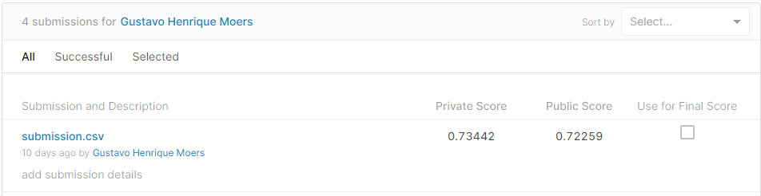

Kaggle Score